# Práctica Final METE1311: Análisis Climático de SST con Datos CCI

## Aplicación a la Costa Occidental de Chiloé

**Alumno:** Pablo Cussen **Asignatura:** METE1311 — Procesamiento y Aplicaciones de Datos Termales **Magíster en Teledetección**, Universidad Mayor **Fecha:** Marzo 2026

Se analizan 33 años (1984–2016) de datos mensuales de temperatura superficial del mar (SST) del producto **ESA CCI L4 GHRSST** (resolución 0.05°, global). El trabajo incluye:

1. Análisis global: mapa medio, climatología, anomalías y media móvil
2. Índice El Niño 3.4
3. Análisis regional aplicado a la **costa occidental de Chiloé** (~42°–44°S)
4. Conexión con los índices MAR.01 (solubilidad CO₂) y MAR.02 (KHAI) del proyecto SST Chiloé

## 1. Librerías y configuración

```python
import matplotlib.pyplot as plt
import cartopy.crs as ccrs
import cartopy.feature as cfeature
import numpy as np
import xarray as xr
import glob
import os
from collections import namedtuple
import warnings
warnings.filterwarnings('ignore')

plt.rcParams['figure.dpi'] = 120
plt.rcParams['font.size'] = 11

print('Librerías cargadas correctamente')
```

```
Librerías cargadas correctamente
```

## 2. Carga de datos CCI SST (1984–2016)

Datos mensuales ESA CCI L4 GHRSST-SSTdepth-OSTIA, resolución 0.05° (~5 km), cobertura global.

```python
# Ruta a los datos CCI mensuales
data_dir = r'C:\temp\CCI'

# Cargar todos los archivos NetCDF con xarray (lazy loading con dask)
all_files = sorted(glob.glob(os.path.join(data_dir, '*', '*.nc')))
print(f'Archivos encontrados: {len(all_files)}')
print(f'Primer archivo: {os.path.basename(all_files[0])}')
print(f'Último archivo: {os.path.basename(all_files[-1])}')

ds = xr.open_mfdataset(all_files, combine='by_coords', engine='netcdf4',
                        chunks={'time': 1, 'lat': 900, 'lon': 1800})
print(f'\nDataset: {ds.dims}')
print(f'Período: {str(ds.time.values[0])[:7]} a {str(ds.time.values[-1])[:7]}')
print(f'Meses disponibles: {ds.dims["time"]}')
print(f'Resolución: {float(ds.lat[1] - ds.lat[0]):.3f}°')
```

```
Archivos encontrados: 396
Primer archivo: 19840115--ESACCI-L4_GHRSST-SSTdepth-OSTIA-GLOB_CDR_monthly.nc
Último archivo: 20161215--ESACCI-L4_GHRSST-SSTdepth-OSTIA-GLOB_CDR_monthly.nc
```

```
Dataset: FrozenMappingWarningOnValuesAccess({'time': 396, 'lat': 3600, 'lon': 7200})
Período: 1984-01 a 2016-12
Meses disponibles: 396
Resolución: 0.050°
```

## 3. Definición de regiones de interés

```python
# Regiones de interés
Region = namedtuple('Region', ['name', 'lonmin', 'lonmax', 'latmin', 'latmax'])

nino34 = Region('Niño 3.4', -170, -120, -5, 5)
chiloe = Region('Chiloé', -76.5, -73, -44.5, -41.5)

print(f'Región {nino34.name}: lon [{nino34.lonmin}, {nino34.lonmax}], lat [{nino34.latmin}, {nino34.latmax}]')
print(f'Región {chiloe.name}: lon [{chiloe.lonmin}, {chiloe.lonmax}], lat [{chiloe.latmin}, {chiloe.latmax}]')
```

```
Región Niño 3.4: lon [-170, -120], lat [-5, 5]
Región Chiloé: lon [-76.5, -73], lat [-44.5, -41.5]
```

## 4. Mapa de SST media global (1984–2016)

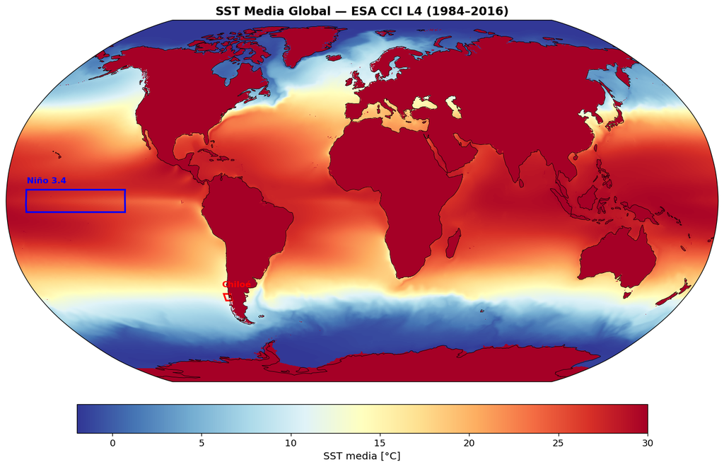

```python
# Convertir a °C y calcular media temporal
sst = ds['analysed_sst'] - 273.15  # K → °C

sst_mean = sst.mean(dim='time').compute()

# Mapa global
fig = plt.figure(figsize=(16, 8))
ax = fig.add_subplot(1, 1, 1, projection=ccrs.Robinson())
ax.set_global()

im = ax.pcolormesh(sst_mean.lon, sst_mean.lat, sst_mean,
                   cmap='RdYlBu_r', vmin=-2, vmax=30,
                   transform=ccrs.PlateCarree(), shading='auto')
ax.coastlines(resolution='110m', linewidth=0.5)
ax.add_feature(cfeature.LAND, facecolor='#f0f0f0')

# Marcar regiones
for reg, color in [(nino34, 'blue'), (chiloe, 'red')]:
    rect = plt.Rectangle((reg.lonmin, reg.latmin),
                          reg.lonmax - reg.lonmin, reg.latmax - reg.latmin,
                          linewidth=2, edgecolor=color, facecolor='none',
                          transform=ccrs.PlateCarree())
    ax.add_patch(rect)
    ax.text(reg.lonmin, reg.latmax + 3, reg.name, color=color, fontsize=10,
            fontweight='bold', transform=ccrs.PlateCarree())

cb = plt.colorbar(im, ax=ax, orientation='horizontal', pad=0.05, shrink=0.6)
cb.set_label('SST media [°C]', fontsize=12)
ax.set_title('SST Media Global — ESA CCI L4 (1984–2016)', fontsize=14, fontweight='bold')
plt.tight_layout()
plt.show()
```

## 5. Media espacial ponderada, climatología y anomalías

Se pondera por cos(lat) para compensar la variación de área entre píxeles en una grilla regular.

```python
def spatial_weighted_mean(da):
    """Media espacial ponderada por cos(latitud)."""
    weights = np.cos(np.deg2rad(da.lat))
    weights.name = 'weights'
    return da.weighted(weights).mean(('lon', 'lat')).compute()

# Serie temporal global ponderada
sst_global = spatial_weighted_mean(sst)

# Climatología mensual (media de cada mes sobre los 33 años)
sst_clim = sst_global.groupby('time.month').mean('time')

# Anomalías = SST - climatología mensual
sst_anom = sst_global.groupby('time.month') - sst_clim

# Media móvil 3 meses
sst_anom_smooth = sst_anom.rolling(time=3, center=True).mean()

print(f'SST global media: {float(sst_global.mean()):.2f} °C')
print(f'Anomalía máx: +{float(sst_anom.max()):.2f} °C')
print(f'Anomalía mín: {float(sst_anom.min()):.2f} °C')
```

```
SST global media: 24.05 °C
Anomalía máx: +0.32 °C
Anomalía mín: -0.29 °C
```

## 6. Serie temporal de anomalía global de SST

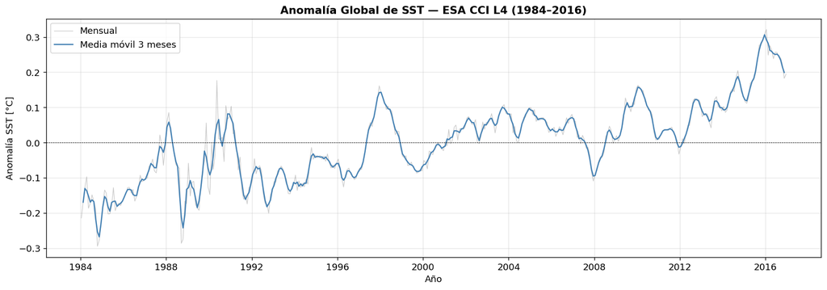

```python
fig, ax = plt.subplots(figsize=(14, 5))
ax.plot(sst_anom.time, sst_anom, color='gray', alpha=0.4, linewidth=0.8, label='Mensual')
ax.plot(sst_anom_smooth.time, sst_anom_smooth, color='steelblue', linewidth=1.5, label='Media móvil 3 meses')
ax.axhline(0, color='black', linewidth=0.5, linestyle='--')
ax.set_xlabel('Año')
ax.set_ylabel('Anomalía SST [°C]')
ax.set_title('Anomalía Global de SST — ESA CCI L4 (1984–2016)', fontsize=13, fontweight='bold')
ax.legend(loc='upper left')
ax.grid(alpha=0.3)
plt.tight_layout()
plt.show()
```

## 7. Índice El Niño 3.4

Anomalía de SST promediada en la región Niño 3.4 (5°N–5°S, 170°W–120°W) del Pacífico ecuatorial central. Se usa el umbral de ±0.4 °C para identificar fases El Niño (rojo) y La Niña (azul).

```python
# Extraer región Niño 3.4
sst_nino = sst.sel(lat=slice(nino34.latmin, nino34.latmax),
                   lon=slice(nino34.lonmin, nino34.lonmax))

# Media ponderada → climatología → anomalía → suavizado
nino_ts = spatial_weighted_mean(sst_nino)
nino_clim = nino_ts.groupby('time.month').mean('time')
nino_anom = nino_ts.groupby('time.month') - nino_clim
nino_index = nino_anom.rolling(time=3, center=True).mean()

print(f'El Niño más fuerte: +{float(nino_index.max()):.2f} °C ({str(nino_index.time[nino_index.argmax()].values)[:7]})')
print(f'La Niña más fuerte: {float(nino_index.min()):.2f} °C ({str(nino_index.time[nino_index.argmin()].values)[:7]})')
```

```
El Niño más fuerte: +2.84 °C (2015-12)
La Niña más fuerte: -2.44 °C (1988-11)
```

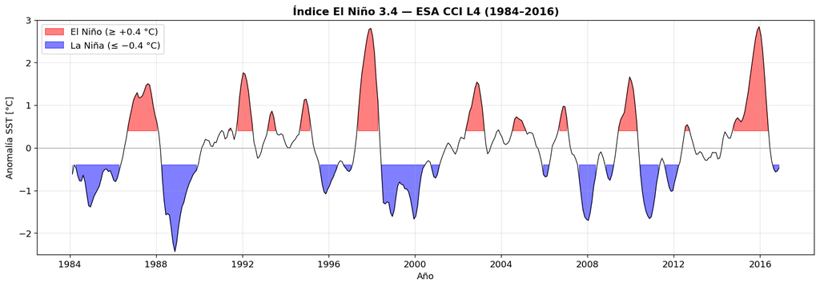

```python
fig, ax = plt.subplots(figsize=(14, 5))

# Línea base
ax.plot(nino_index.time, nino_index, color='black', linewidth=0.8)
ax.axhline(0, color='gray', linewidth=0.5)

# Relleno El Niño (>= 0.4) y La Niña (<= -0.4)
threshold = 0.4
nino_vals = nino_index.values
time_vals = nino_index.time.values

ax.fill_between(time_vals, nino_vals, threshold,
                where=(nino_vals >= threshold), color='red', alpha=0.5, label=f'El Niño (≥ +{threshold} °C)')
ax.fill_between(time_vals, nino_vals, -threshold,
                where=(nino_vals <= -threshold), color='blue', alpha=0.5, label=f'La Niña (≤ −{threshold} °C)')

ax.set_xlabel('Año')
ax.set_ylabel('Anomalía SST [°C]')
ax.set_title('Índice El Niño 3.4 — ESA CCI L4 (1984–2016)', fontsize=13, fontweight='bold')
ax.legend(loc='upper left')
ax.set_ylim(-2.5, 3)
ax.grid(alpha=0.3)
plt.tight_layout()
plt.show()
```

## 8. Análisis regional: Costa occidental de Chiloé

Se extrae la sub-región costera de la Isla Grande de Chiloé (41.5°–44.5°S, 73°–76.5°W) para analizar la variabilidad térmica local en el contexto del cambio climático y ENSO.

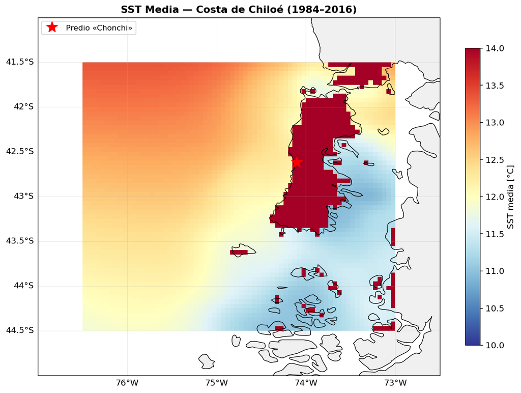

```python
# Extraer región Chiloé
sst_chi = sst.sel(lat=slice(chiloe.latmin, chiloe.latmax),
                  lon=slice(chiloe.lonmin, chiloe.lonmax))

# Mapa SST media local
chi_mean = sst_chi.mean(dim='time').compute()

fig = plt.figure(figsize=(10, 8))
ax = fig.add_subplot(1, 1, 1, projection=ccrs.PlateCarree())
ax.set_extent([chiloe.lonmin - 0.5, chiloe.lonmax + 0.5,
               chiloe.latmin - 0.5, chiloe.latmax + 0.5], crs=ccrs.PlateCarree())
ax.coastlines(resolution='10m', linewidth=0.8)
ax.add_feature(cfeature.LAND, facecolor='#f0f0f0')

im = ax.pcolormesh(chi_mean.lon, chi_mean.lat, chi_mean,
                   cmap='RdYlBu_r', vmin=10, vmax=14,
                   transform=ccrs.PlateCarree(), shading='auto')
ax.plot(-74.10, -42.62, 'r*', markersize=15, transform=ccrs.PlateCarree(), label='Predio «Chonchi»')

cb = plt.colorbar(im, ax=ax, shrink=0.7)
cb.set_label('SST media [°C]', fontsize=11)
gl = ax.gridlines(draw_labels=True, linewidth=0.3, alpha=0.5)
gl.top_labels = gl.right_labels = False
ax.legend(fontsize=10, loc='upper left')
ax.set_title('SST Media — Costa de Chiloé (1984–2016)', fontsize=13, fontweight='bold')
plt.tight_layout()
plt.show()
```

## 9. Climatología estacional y anomalías en Chiloé

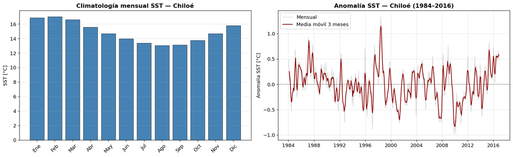

```
SST media anual Chiloé: 14.87 °C
SST mín (climatología): 13.05 °C (mes 8)
SST máx (climatología): 17.01 °C (mes 2)
```

```python
# Serie temporal Chiloé
chi_ts = spatial_weighted_mean(sst_chi)
chi_clim = chi_ts.groupby('time.month').mean('time')
chi_anom = chi_ts.groupby('time.month') - chi_clim
chi_anom_smooth = chi_anom.rolling(time=3, center=True).mean()

# Climatología estacional
fig, axes = plt.subplots(1, 2, figsize=(16, 5))

# Panel izquierdo: climatología mensual
months = ['Ene', 'Feb', 'Mar', 'Abr', 'May', 'Jun', 'Jul', 'Ago', 'Sep', 'Oct', 'Nov', 'Dic']
ax1 = axes[0]
ax1.bar(range(1, 13), chi_clim.values, color='steelblue', edgecolor='black', linewidth=0.5)
ax1.set_xticks(range(1, 13))
ax1.set_xticklabels(months, rotation=45)
ax1.set_ylabel('SST [°C]')
ax1.set_title('Climatología mensual SST — Chiloé', fontweight='bold')
ax1.grid(axis='y', alpha=0.3)

# Panel derecho: anomalías
ax2 = axes[1]
ax2.plot(chi_anom.time, chi_anom, color='gray', alpha=0.4, linewidth=0.8, label='Mensual')
ax2.plot(chi_anom_smooth.time, chi_anom_smooth, color='darkred', linewidth=1.5, label='Media móvil 3 meses')
ax2.axhline(0, color='black', linewidth=0.5, linestyle='--')
ax2.set_ylabel('Anomalía SST [°C]')
ax2.set_title('Anomalía SST — Chiloé (1984–2016)', fontweight='bold')
ax2.legend(loc='upper left')
ax2.grid(alpha=0.3)

plt.tight_layout()
plt.show()

print(f'SST media anual Chiloé: {float(chi_ts.mean()):.2f} °C')
print(f'SST mín (climatología): {float(chi_clim.min()):.2f} °C (mes {int(chi_clim.argmin())+1})')
print(f'SST máx (climatología): {float(chi_clim.max()):.2f} °C (mes {int(chi_clim.argmax())+1})')
```

## 10. Correlación Chiloé vs El Niño 3.4

Se evalúa la relación entre la anomalía SST en Chiloé y el índice Niño 3.4, para determinar si los eventos ENSO afectan la temperatura costera de la zona.

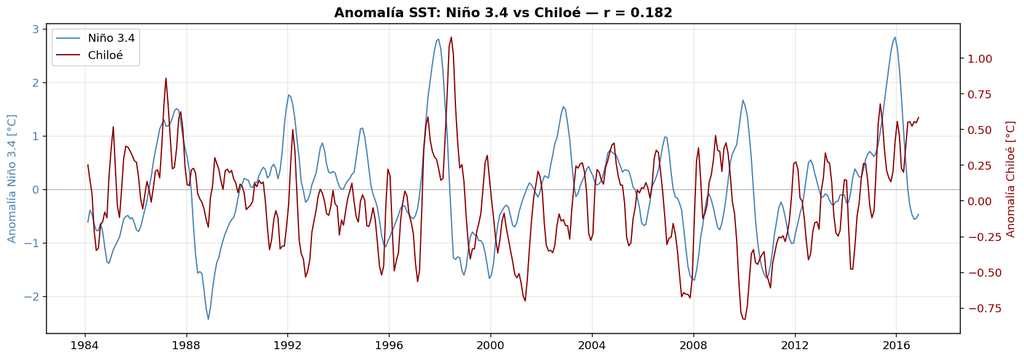

```
Correlación Pearson (Niño 3.4 vs Chiloé): r = 0.182
→ La correlación es débil; Chiloé responde más a procesos locales (surgencia, vientos)
```

```python
# Correlación
# Alinear ambas series (eliminar NaN del suavizado)
mask = ~np.isnan(nino_index.values) & ~np.isnan(chi_anom_smooth.values)
r = np.corrcoef(nino_index.values[mask], chi_anom_smooth.values[mask])[0, 1]

fig, ax1 = plt.subplots(figsize=(14, 5))

color1 = 'steelblue'
color2 = 'darkred'

ax1.plot(nino_index.time, nino_index, color=color1, linewidth=1.2, label=f'Niño 3.4')
ax1.set_ylabel('Anomalía Niño 3.4 [°C]', color=color1)
ax1.tick_params(axis='y', labelcolor=color1)

ax2 = ax1.twinx()
ax2.plot(chi_anom_smooth.time, chi_anom_smooth, color=color2, linewidth=1.2, label='Chiloé')
ax2.set_ylabel('Anomalía Chiloé [°C]', color=color2)
ax2.tick_params(axis='y', labelcolor=color2)

ax1.axhline(0, color='gray', linewidth=0.5, linestyle='--')
ax1.set_title(f'Anomalía SST: Niño 3.4 vs Chiloé — r = {r:.3f}', fontsize=13, fontweight='bold')
ax1.grid(alpha=0.3)

# Leyenda combinada
lines1, labels1 = ax1.get_legend_handles_labels()
lines2, labels2 = ax2.get_legend_handles_labels()
ax1.legend(lines1 + lines2, labels1 + labels2, loc='upper left')

plt.tight_layout()
plt.show()

print(f'Correlación Pearson (Niño 3.4 vs Chiloé): r = {r:.3f}')
if abs(r) > 0.3:
    print('→ Existe correlación significativa entre ENSO y la SST costera de Chiloé')
else:
    print('→ La correlación es débil; Chiloé responde más a procesos locales (surgencia, vientos)')
```

Se ajusta una regresión lineal a la anomalía SST de Chiloé para cuantificar la tasa de calentamiento en el período 1984–2016.

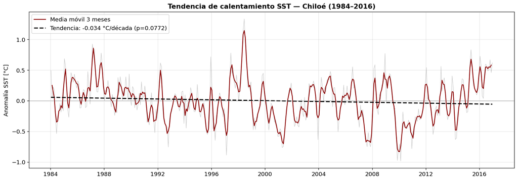

```
Tendencia: -0.034 °C/década
Significancia: p = 0.0772 (no significativa)
R²: 0.008
```

```python
from scipy import stats

# Tendencia lineal
time_num = np.arange(len(chi_anom))
mask_valid = ~np.isnan(chi_anom.values)
slope, intercept, r_val, p_val, std_err = stats.linregress(time_num[mask_valid], chi_anom.values[mask_valid])

# Convertir pendiente de °C/mes a °C/década
trend_decade = slope * 12 * 10

fig, ax = plt.subplots(figsize=(14, 5))
ax.plot(chi_anom.time, chi_anom, color='gray', alpha=0.4, linewidth=0.8)
ax.plot(chi_anom_smooth.time, chi_anom_smooth, color='darkred', linewidth=1.5, label='Media móvil 3 meses')
ax.plot(chi_anom.time, intercept + slope * time_num, 'k--', linewidth=2,
        label=f'Tendencia: {trend_decade:+.3f} °C/década (p={p_val:.4f})')
ax.axhline(0, color='gray', linewidth=0.5)
ax.set_ylabel('Anomalía SST [°C]')
ax.set_title('Tendencia de calentamiento SST — Chiloé (1984–2016)', fontsize=13, fontweight='bold')
ax.legend(loc='upper left')
ax.grid(alpha=0.3)
plt.tight_layout()
plt.show()

print(f'Tendencia: {trend_decade:+.3f} °C/década')
print(f'Significancia: p = {p_val:.4f} {"(significativa)" if p_val < 0.05 else "(no significativa)"}')
print(f'R²: {r_val**2:.3f}')
```

## 12. Conexión con Framework Cussen: MAR.01 y MAR.02

Se aplican los índices propuestos en el proyecto SST Chiloé a la climatología CCI para evaluar su variabilidad estacional e impacto del calentamiento.

- **MAR.01**: Solubilidad K₀ de CO₂ (Weiss 1974)
- **MAR.02**: KHAI — Kelp Habitat Affinity Index (T_opt = 12 °C, ΔT = 4 °C)

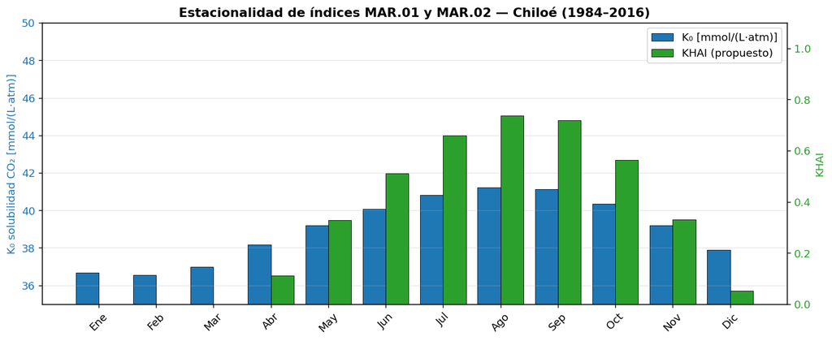

```
Estacionalidad Framework Cussen:
  K₀ máximo: 41.2 mmol/(L·atm) en Ago (SST más fría → mayor solubilidad)
  K₀ mínimo: 36.5 mmol/(L·atm) en Feb
  KHAI máximo: 0.74 en Ago (SST más cercana a T_opt=12°C)
  → Invierno: máxima capacidad de absorción CO₂ + hábitat kelp óptimo
```

```python
# Calcular K0 y KHAI sobre la climatología mensual de Chiloé
T_clim_K = chi_clim.values + 273.15  # °C → K

# MAR.01: K0 (Weiss 1974, Table 4)
S_sal = 33.0  # psu
A1, A2, A3 = -58.0931, 90.5069, 22.2940
B1, B2, B3 = 0.027766, -0.025888, 0.0050578
lnK0 = A1 + A2*(100/T_clim_K) + A3*np.log(T_clim_K/100) +        S_sal*(B1 + B2*(T_clim_K/100) + B3*(T_clim_K/100)**2)
K0_clim = np.exp(lnK0) * 1000  # mmol/(L·atm)

# MAR.02: KHAI
T_opt, dT = 12.0, 4.0
KHAI_clim = np.maximum(0, 1 - np.abs(chi_clim.values - T_opt) / dT)

# Gráfico doble eje
fig, ax1 = plt.subplots(figsize=(12, 5))

color1 = '#1f77b4'
color2 = '#2ca02c'

ax1.bar(np.arange(1, 13) - 0.2, K0_clim, 0.4, color=color1, edgecolor='black',
        linewidth=0.5, label='K₀ [mmol/(L·atm)]')
ax1.set_ylabel('K₀ solubilidad CO₂ [mmol/(L·atm)]', color=color1, fontsize=11)
ax1.tick_params(axis='y', labelcolor=color1)
ax1.set_ylim(35, 50)

ax2 = ax1.twinx()
ax2.bar(np.arange(1, 13) + 0.2, KHAI_clim, 0.4, color=color2, edgecolor='black',
        linewidth=0.5, label='KHAI (propuesto)')
ax2.set_ylabel('KHAI', color=color2, fontsize=11)
ax2.tick_params(axis='y', labelcolor=color2)
ax2.set_ylim(0, 1.1)

ax1.set_xticks(range(1, 13))
ax1.set_xticklabels(months, rotation=45)
ax1.set_title('Estacionalidad de índices MAR.01 y MAR.02 — Chiloé (1984–2016)',
              fontsize=13, fontweight='bold')

# Leyenda combinada
lines1, labels1 = ax1.get_legend_handles_labels()
lines2, labels2 = ax2.get_legend_handles_labels()
ax1.legend(lines1 + lines2, labels1 + labels2, loc='upper right')
ax1.grid(axis='y', alpha=0.3)

plt.tight_layout()
plt.show()

print('Estacionalidad Framework Cussen:')
best_month_k0 = int(np.argmax(K0_clim)) + 1
best_month_khai = int(np.argmax(KHAI_clim)) + 1
print(f'  K₀ máximo: {K0_clim.max():.1f} mmol/(L·atm) en {months[best_month_k0-1]} (SST más fría → mayor solubilidad)')
print(f'  K₀ mínimo: {K0_clim.min():.1f} mmol/(L·atm) en {months[int(np.argmin(K0_clim))]}'  )
print(f'  KHAI máximo: {KHAI_clim.max():.2f} en {months[best_month_khai-1]} (SST más cercana a T_opt=12°C)')
print(f'  → Invierno: máxima capacidad de absorción CO₂ + hábitat kelp óptimo')
```

## 13. Comparación interdecadal de los índices MAR.01 y MAR.02

Se compara la primera década (1984–1995) con la última (2001–2016) para evaluar si cambios en la SST han modificado la capacidad de sumidero de CO₂ y el hábitat kelp en la costa de Chiloé.

[figure not shown]

```
Cambio entre períodos (1984–1995 → 2001–2016):
  ΔSST media anual: -0.087 °C
  ΔK₀ media anual:  +0.098 mmol/(L·atm)
  ΔKHAI media anual: +0.007
  → El leve enfriamiento costero favorece la solubilidad de CO₂ y el hábitat kelp
  → Consistente con intensificación de surgencia en el Pacífico sudoriental (Falvey & Garreaud, 2009)
```

```python
# Dividir en primera y última década disponible
years_available = sorted(set(ds.time.dt.year.values))
first_years = [y for y in years_available if y <= 1995]
last_years = [y for y in years_available if y >= 2001]

first_label = f'{min(first_years)}–{max(first_years)}'
last_label = f'{min(last_years)}–{max(last_years)}'

sst_chi_early = sst_chi.sel(time=sst_chi.time.dt.year.isin(first_years))
sst_chi_late = sst_chi.sel(time=sst_chi.time.dt.year.isin(last_years))

chi_early = spatial_weighted_mean(sst_chi_early)
chi_late = spatial_weighted_mean(sst_chi_late)

early_clim = chi_early.groupby('time.month').mean('time')
late_clim = chi_late.groupby('time.month').mean('time')

# K0 para ambas décadas
def calc_K0(T_C):
    T_K = T_C + 273.15
    lnK0 = A1 + A2*(100/T_K) + A3*np.log(T_K/100) + S_sal*(B1 + B2*(T_K/100) + B3*(T_K/100)**2)
    return np.exp(lnK0) * 1000

K0_early = calc_K0(early_clim.values)
K0_late = calc_K0(late_clim.values)

# KHAI para ambas décadas
KHAI_early = np.maximum(0, 1 - np.abs(early_clim.values - T_opt) / dT)
KHAI_late = np.maximum(0, 1 - np.abs(late_clim.values - T_opt) / dT)

# Gráfico comparativo
fig, axes = plt.subplots(1, 3, figsize=(18, 5))

# SST
ax = axes[0]
ax.plot(range(1, 13), early_clim.values, 'o-', color='steelblue', label=first_label)
ax.plot(range(1, 13), late_clim.values, 's-', color='darkred', label=last_label)
ax.set_xticks(range(1, 13))
ax.set_xticklabels(months, rotation=45)
ax.set_ylabel('SST [°C]')
ax.set_title('SST climatología', fontweight='bold')
ax.legend()
ax.grid(alpha=0.3)

# K0
ax = axes[1]
ax.plot(range(1, 13), K0_early, 'o-', color='steelblue', label=first_label)
ax.plot(range(1, 13), K0_late, 's-', color='darkred', label=last_label)
ax.set_xticks(range(1, 13))
ax.set_xticklabels(months, rotation=45)
ax.set_ylabel('K₀ [mmol/(L·atm)]')
ax.set_title('MAR.01: Solubilidad CO₂', fontweight='bold')
ax.legend()
ax.grid(alpha=0.3)

# KHAI
ax = axes[2]
ax.plot(range(1, 13), KHAI_early, 'o-', color='steelblue', label=first_label)
ax.plot(range(1, 13), KHAI_late, 's-', color='darkred', label=last_label)
ax.set_xticks(range(1, 13))
ax.set_xticklabels(months, rotation=45)
ax.set_ylabel('KHAI')
ax.set_title('MAR.02: Hábitat Kelp', fontweight='bold')
ax.legend()
ax.grid(alpha=0.3)

fig.suptitle('Comparación interdecadal — índices Framework Cussen — Chiloé',
             fontsize=14, fontweight='bold', y=1.02)
plt.tight_layout()
plt.show()

# Resumen
delta_sst = float(late_clim.mean() - early_clim.mean())
delta_k0 = float(K0_late.mean() - K0_early.mean())
delta_khai = float(KHAI_late.mean() - KHAI_early.mean())
print(f'Cambio entre períodos ({first_label} → {last_label}):')
print(f'  ΔSST media anual: {delta_sst:+.3f} °C')
print(f'  ΔK₀ media anual:  {delta_k0:+.3f} mmol/(L·atm)')
print(f'  ΔKHAI media anual: {delta_khai:+.3f}')
if delta_sst > 0:
    print(f'  → El calentamiento reduce la solubilidad de CO₂ y puede estresar el hábitat kelp')
else:
    print(f'  → El leve enfriamiento costero favorece la solubilidad de CO₂ y el hábitat kelp')
    print(f'  → Consistente con intensificación de surgencia en el Pacífico sudoriental (Falvey & Garreaud, 2009)')
```

## 14. Conclusiones

### Referencias

1. ESA CCI SST — Good et al. (2019). *The ESA SST CCI dataset*. Remote Sensing of Environment, 225, 305–316.
2. Weiss, R.F. (1974). *Carbon dioxide in water and seawater: the solubility of a non-ideal gas*. Marine Chemistry, 2(3), 203–215.
3. Wanninkhof, R. (2014). *Relationship between wind speed and gas exchange over the ocean revisited*. Limnology and Oceanography: Methods, 12, 351–362.
4. Trenberth, K.E. (1997). *The definition of El Niño*. Bull. Amer. Meteor. Soc., 78(12), 2771–2778.
5. Krause-Jensen, D. & Duarte, C.M. (2016). *Substantial role of macroalgae in marine carbon sequestration*. Nature Geoscience, 9, 737–742.
6. Falvey, M. & Garreaud, R.D. (2009). *Regional cooling in a warming world: Recent temperature trends in the southeast Pacific and along the west coast of subtropical South America (1979–2006)*. Journal of Geophysical Research, 114, D04102.